# Project2

Kylie Wakefield

4/9/2020

# Project 2

The data for this project is from the United States Census Bureau. The data was taken from a population of individuals over the age of 15 in the year 2018. The variables highlight the percentage of individuals in a specific marital category of the population. The population is defined by five different categories: gender, the age group, income ($), and percentage of individuals in a specific marital status. There are a toatl of eight variables. The marital status percentages show those who are married, have never been married, widowed, separated, or divorced. The gender shows whether the percentage reflects information for males or females. There are 6 age groups in which the data was taken: 15-19, 20-34, 35-44, 45-54, 55-64, and 65 or older. The “income” is the average income for each age group (it is the same for males and females). There are 12 observations for each variable, for a total of 96 observations.

## Setup

```r
library(tinytex)
library(readxl)
marriage<-read_excel("/Users/kyliewakefield/Documents/UT/Spring 2020/Website/content/dataproject2.xlsx")
```

## MANOVA/ANOVA Testing

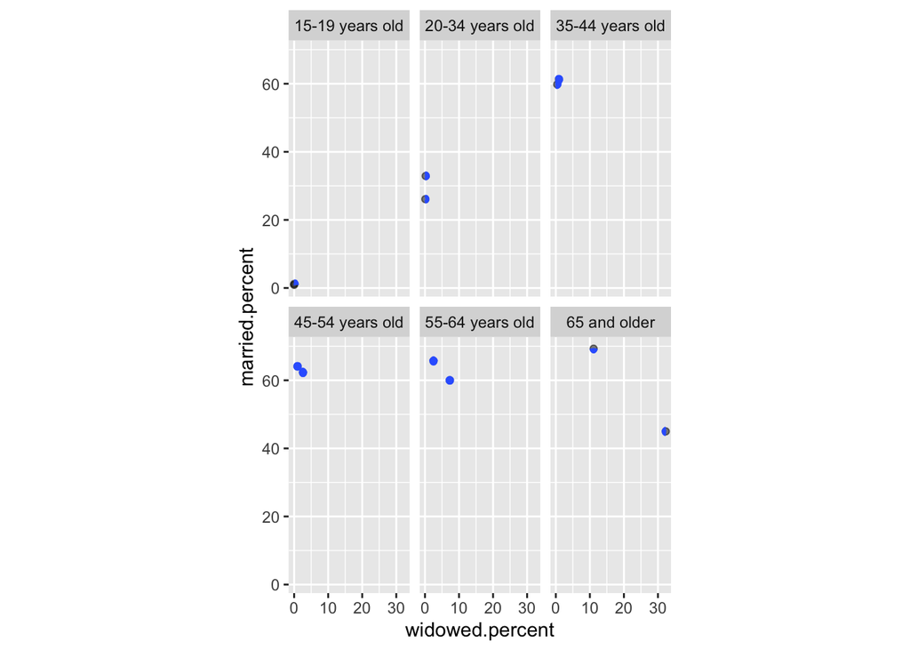

```r
#assumptions
library(ggplot2)
library(tidyverse)
ggplot(marriage, aes(x = widowed.percent, y = married.percent)) + geom_point(alpha = .5) + geom_density_2d(h=2) + coord_fixed() + facet_wrap(~age.group)
```

```r
covmats<-marriage%>%group_by(age.group)%>%do(covs=cov(.[6:7]))
for (i in 2:7) {print(as.character(covmats$age.group[i])); print(covmats$covs[i])}
```

```
## [1] "20-34 years old"
## [[1]]
##                      nevermarried.percent married.percent
## nevermarried.percent                38.72          -29.92
## married.percent                    -29.92           23.12
##
## [1] "35-44 years old"
## [[1]]
##                      nevermarried.percent married.percent
## nevermarried.percent               16.245          -4.275
## married.percent                    -4.275           1.125
##
## [1] "45-54 years old"
## [[1]]
##                      nevermarried.percent married.percent
## nevermarried.percent                6.845            3.33
## married.percent                     3.330            1.62
##
## [1] "55-64 years old"
## [[1]]
##                      nevermarried.percent married.percent
## nevermarried.percent                 3.38           7.410
## married.percent                      7.41          16.245
##
## [1] "65 and older"
## [[1]]
##                      nevermarried.percent married.percent
## nevermarried.percent                 0.02           2.430
## married.percent                      2.43         295.245
##
## [1] NA
## [[1]]
## NULL
```

```r
#manova
manova<-manova(cbind(married.percent,widowed.percent)~age.group, data=marriage)
summary(manova)
```

```
##           Df Pillai approx F num Df den Df   Pr(>F)
## age.group  5 1.6482   5.6217     10     12 0.003249 **
## Residuals  6
## ---
## Signif. codes:  0 '***' 0.001 '**' 0.01 '*' 0.05 '.' 0.1 ' ' 1
```

```r
#univariate anova
summary.aov(manova)
```

```
##  Response married.percent :
##             Df Sum Sq Mean Sq F value    Pr(>F)
## age.group    5 6416.1 1283.22   22.82 0.0007728 ***
## Residuals    6  337.4   56.23
## ---
## Signif. codes:  0 '***' 0.001 '**' 0.01 '*' 0.05 '.' 0.1 ' ' 1
##
##  Response widowed.percent :
##             Df Sum Sq Mean Sq F value Pr(>F)
## age.group    5 712.96 142.591     3.6 0.0752 .
## Residuals    6 237.65  39.608
## ---
## Signif. codes:  0 '***' 0.001 '**' 0.01 '*' 0.05 '.' 0.1 ' ' 1
```

```r
#post-hoc t-tests for married individuals and age group
pairwise.t.test(marriage$married.percent,marriage$age.group,p.adj="none")
```

```
##
##  Pairwise comparisons using t tests with pooled SD
##
## data:  marriage$married.percent and marriage$age.group
##
##                 15-19 years old 20-34 years old 35-44 years old 45-54 years old
## 20-34 years old 0.00903         -               -               -
## 35-44 years old 0.00021         0.00607         -               -
## 45-54 years old 0.00017         0.00413         0.73588         -
## 55-64 years old 0.00017         0.00434         0.76943         0.96429
## 65 and older    0.00029         0.01024         0.66620         0.45058
##                 55-64 years old
## 20-34 years old -
## 35-44 years old -
## 45-54 years old -
## 55-64 years old -
## 65 and older    0.47598
##
## P value adjustment method: none
```

```r
#probability of a type I error
1-(.95^(18))
```

```
## [1] 0.6027857
```

```r
#Bonferroni correction
0.05/18
```

```
## [1] 0.002777778
```

## Randomization Testing

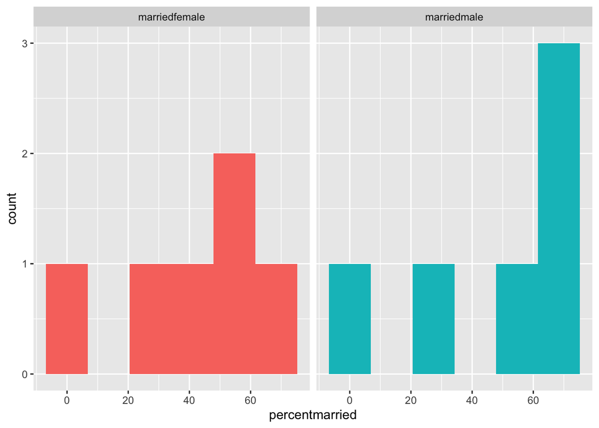

```r
#creating the data frame
marriedmale<-c(0.9,26.1,59.8,64.1,65.7,69.3)
marriedfemale<-c(1.2,32.9,61.3,62.3,60.0,45.0)

#creating the data.frame
cric<-data.frame(gender=c(rep("marriedmale",6),rep("marriedfemale",6)), percentmarried=c(marriedmale,marriedfemale))
#the null statistics
ggplot(cric,aes(percentmarried,fill=gender))+geom_histogram(bins=6.5)+facet_wrap(~gender,ncol=2)+theme(legend.position="none")
```

```r
#mean difference
cric%>%group_by(gender)%>%summarize(means=mean(percentmarried))%>%summarize(`mean_diff:`=diff(means))
```

```
## # A tibble: 1 x 1
##   `mean_diff:`
##          <dbl>
## 1         3.87
```

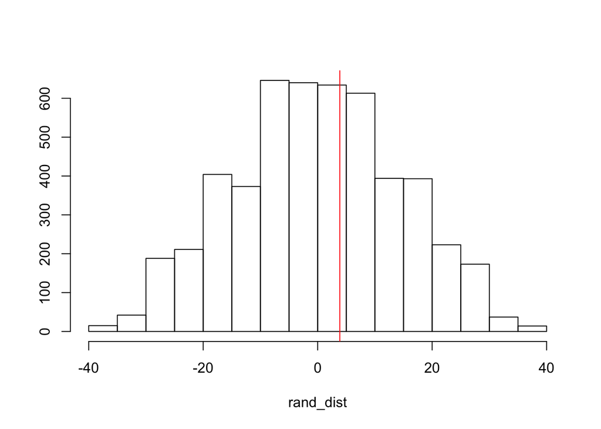

```r
#randomization
rand_dist<-vector()
for(i in 1:5000){
new<-data.frame(percentmarried=sample(cric$percentmarried),gender=cric$gender)
rand_dist[i]<-mean(new[new$gender=="marriedmale",]$percentmarried)-
              mean(new[new$gender=="marriedfemale",]$percentmarried)}
#histogram of the data
{hist(rand_dist,main="",ylab=""); abline(v = 3.866667,col="red")}
```

```r
#p-value
mean(rand_dist>3.866667 | rand_dist< -3.866667)
```

```
## [1] 0.806
```

## Linear Regression Model

```r
library(lmtest)
library(sandwich)
#mean center numeric variable
centered<-data.frame(nevermarried.percent=marriage$nevermarried.percent,married_c=marriage$married.percent-mean(marriage$married.percent),income_c=marriage$income.dollars-mean(marriage$income.dollars))
#regression
fit<-lm(nevermarried.percent ~ income_c*married_c, data = centered)
summary(fit)
```

```
##
## Call:
## lm(formula = nevermarried.percent ~ income_c * married_c, data = centered)
##
## Residuals:
##      Min       1Q   Median       3Q      Max
## -26.1091  -3.1614   0.0811   7.5893  11.8816
##
## Coefficients:
##                      Estimate Std. Error t value Pr(>|t|)
## (Intercept)         3.416e+01  6.264e+00   5.454 0.000606 ***
## income_c           -1.017e-03  1.372e-03  -0.742 0.479510
## married_c          -7.981e-01  5.999e-01  -1.330 0.220045
## income_c:married_c  1.156e-05  2.108e-05   0.548 0.598465
## ---
## Signif. codes:  0 '***' 0.001 '**' 0.01 '*' 0.05 '.' 0.1 ' ' 1
##
## Residual standard error: 12.24 on 8 degrees of freedom
## Multiple R-squared:  0.9137, Adjusted R-squared:  0.8814
## F-statistic: 28.25 on 3 and 8 DF,  p-value: 0.0001314
```

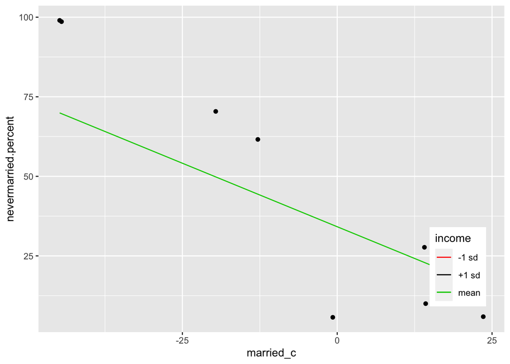

```r
#GGplot
new1<-centered
new1$income_c<-mean(centered$income_c)
new1$mean<-predict(fit,new1)
new1$income_c<-mean(marriage$income_c)+sd(marriage$income_c)
new1$plus.sd<-predict(fit,new1)
new1$income_c<-mean(marriage$income_c)-sd(marriage$income_c)
new1$minus.sd<-predict(fit,new1)
newint<-new1%>%select(nevermarried.percent,married_c,mean,plus.sd,minus.sd)%>%gather(income.dollars,value,-nevermarried.percent,-married_c)

mycols<-c("#619CFF","#F8766D","#00BA38")
names(mycols)<-c("-1 sd","mean","+1 sd")
mycols=as.factor(mycols)

ggplot(centered,aes(married_c,nevermarried.percent),group=mycols)+geom_point()+geom_line(data=new1,aes(y=mean,color="mean"))+geom_line(data=new1,aes(y=plus.sd,color="+1 sd"))+geom_line(data=new1,aes(y=minus.sd,color="-1 sd"))+scale_color_manual(values=mycols)+labs(color="income")+theme(legend.position=c(.9,.2))
```

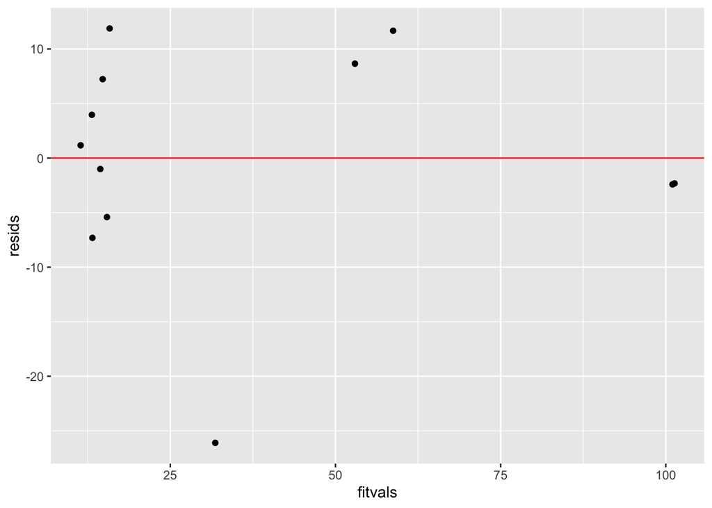

```r
#assumptions
#assumptions: linearity, normality, homoskedasticity
resids<-fit$residuals
fitvals<-fit$fitted.values
ggplot()+geom_point(aes(fitvals,resids))+geom_hline(yintercept = 0, color="red")
```

```r
ks.test(resids, "pnorm", mean=0, sd(resids))
```

```
##
##  One-sample Kolmogorov-Smirnov test
##
## data:  resids
## D = 0.15866, p-value = 0.8776
## alternative hypothesis: two-sided
```

```r
shapiro.test(resids)
```

```
##
##  Shapiro-Wilk normality test
##
## data:  resids
## W = 0.88629, p-value = 0.1055
```

```r
bptest(fit)
```

```
##
##  studentized Breusch-Pagan test
##
## data:  fit
## BP = 4.9166, df = 3, p-value = 0.178
```

```r
#robust SE
coeftest(fit, vcov=vcovHC(fit))
```

```
##
## t test of coefficients:
##
##                       Estimate  Std. Error t value Pr(>|t|)
## (Intercept)         3.4164e+01  1.2693e+01  2.6917  0.02743 *
## income_c           -1.0175e-03  3.9165e-03 -0.2598  0.80159
## married_c          -7.9812e-01  1.8452e+00 -0.4325  0.67677
## income_c:married_c  1.1558e-05  3.2931e-05  0.3510  0.73468
## ---
## Signif. codes:  0 '***' 0.001 '**' 0.01 '*' 0.05 '.' 0.1 ' ' 1
```

###For my linear regression model, I wanted to test how the percentages of individuals who have never been married are affected by income and the percentage of those who are married. When interpreting the regression results, there are multiple coefficients. When income and percent marrried decrease on average, the percent never married increases on average by 3.416e+01.For every increase in income by 1, the average percent never married decreases by -1.017e-03. For every increase in average percent married by 1, the average percent never married decreases by -7.981e-01. There is no significance between income and married percent with the percent never married. The best fitting line: %nevermarried= 3.416e+01 + -1.017e-03(income_c) + -7.981e-01(married_c). The ggplot highlights these relationships. The Kolmogorov-Smirnov test shows that the data is normal (p>0.001). Shapiro-Wilk normality test also highlights that the data is also normal since the p value is greater than 0.001. The ggplot shows that the data is relatively normal. But there are few data points so it is harder to tell. To formally test homoskedasticity, a Breusch-Pagan test was run. Since the p value is greater than 0.001, the data is homoskedastic. After running the robust SE test, the only change was the intercept p value. In the SE test, the p value changed from 0.000606 to 0.02743, so it made the intercept less significant. But the SE are larger for some of the variables in the SE test, so it is best to go with these estimates.

## Bootstrapping

```r
samp_distn<-replicate(5000, {
  boot_dat<-boot_dat<-centered[sample(nrow(centered), replace=TRUE),]
  fit2<-lm(nevermarried.percent~income_c*married_c, data = boot_dat)
  coef(fit2)
})
samp_distn%>%t%>%as.data.frame%>%summarise_all(sd)
```

```
##   (Intercept)    income_c married_c income_c:married_c
## 1    43.91205 0.005867756   2.61751       0.0002777457
```

## Logistic Regression

```r
class_diag <- function(probs,truth){
  tab<-table(factor(probs>.5,levels=c("FALSE","TRUE")),truth)
  acc=sum(diag(tab))/sum(tab)
  sens=tab[2,2]/colSums(tab)[2]
  spec=tab[1,1]/colSums(tab)[1]
  ppv=tab[2,2]/rowSums(tab)[2]
  if(is.numeric(truth)==FALSE & is.logical(truth)==FALSE) truth<-as.numeric(truth)-1
  ord<-order(probs, decreasing=TRUE)
  probs<-probs[ord]; truth <- truth[ord]
  TPR=cumsum(truth)/max(1,sum(truth))
  FPR=cumsum(!truth)/max(1,sum(!truth))
  dup<-c(probs[-1]>=probs[-length(probs)], FALSE)
  TPR<-c(0,TPR[!dup],1); FPR<-c(0,FPR[!dup],1)
  n <- length(TPR)
  auc<- sum( ((TPR[-1]+TPR[-n])/2) * (FPR[-1]-FPR[-n]) )
  data.frame(acc,sens,spec,ppv,auc)
}
#binary categorical variable
marriage$highincome<-if_else(marriage$income.dollars>median(marriage$income.dollars),1,0)
fit<-glm(highincome~nevermarried.percent+married.percent, data = marriage, family = "binomial"(link = "logit"))
coeftest(fit)
```

```
##
## z test of coefficients:
##
##                        Estimate Std. Error z value Pr(>|z|)
## (Intercept)          -12.967533  11.385386 -1.1390   0.2547
## nevermarried.percent   0.065218   0.103671  0.6291   0.5293
## married.percent        0.214698   0.162208  1.3236   0.1856
```

```r
#e^(estimate)
exp(coef(fit))
```

```
##          (Intercept) nevermarried.percent      married.percent
##         2.334920e-06         1.067392e+00         1.239488e+00
```

```r
probs<-predict(fit, type = "response")
class_diag(probs,marriage$highincome)
```

```
##         acc sens      spec       ppv       auc
## 1 0.9166667    1 0.8333333 0.8571429 0.8333333
```

```r
pred<-ifelse(probs>.5,1,0)

#confusion matrix
table(prediction=pred, truth=marriage$highincome)%>%addmargins
```

```
##           truth
## prediction  0  1 Sum
##        0    5  0   5
##        1    1  6   7
##        Sum  6  6  12
```

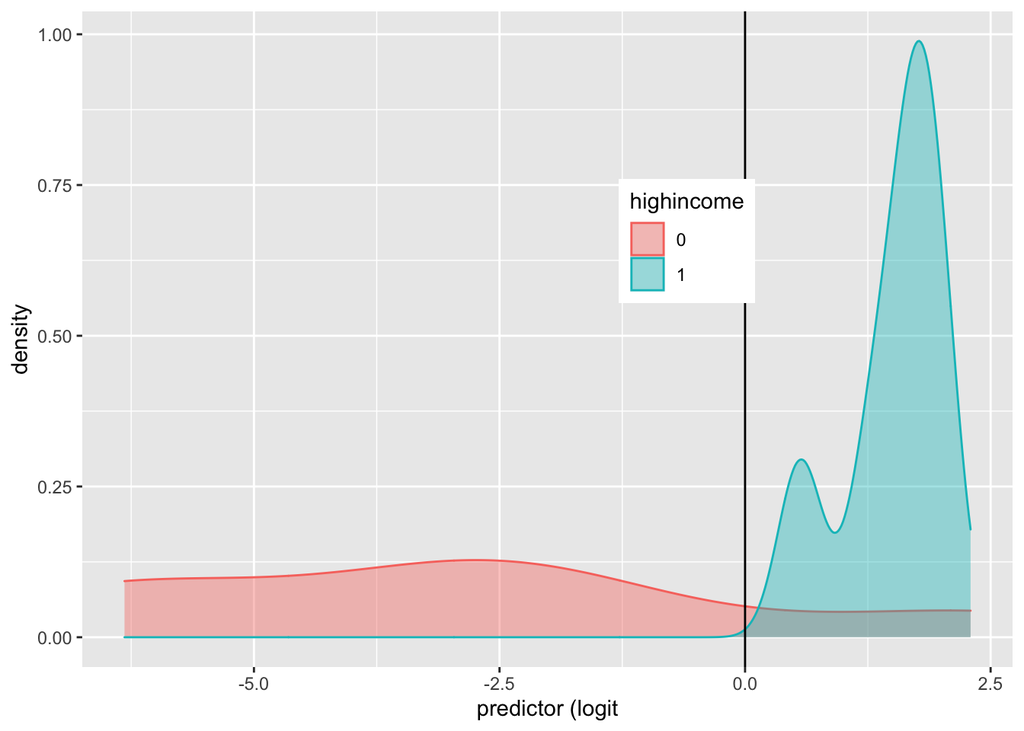

```r
#density plot
density<-marriage
density$highincome<-as.factor(density$highincome)
density$logit<-predict(fit, type = "link")
density%>%ggplot(aes(logit,color=highincome,fill=highincome))+geom_density(alpha=.4)+theme(legend.position = c(.65,.65))+geom_vline(xintercept = 0)+xlab("predictor (logit")
```

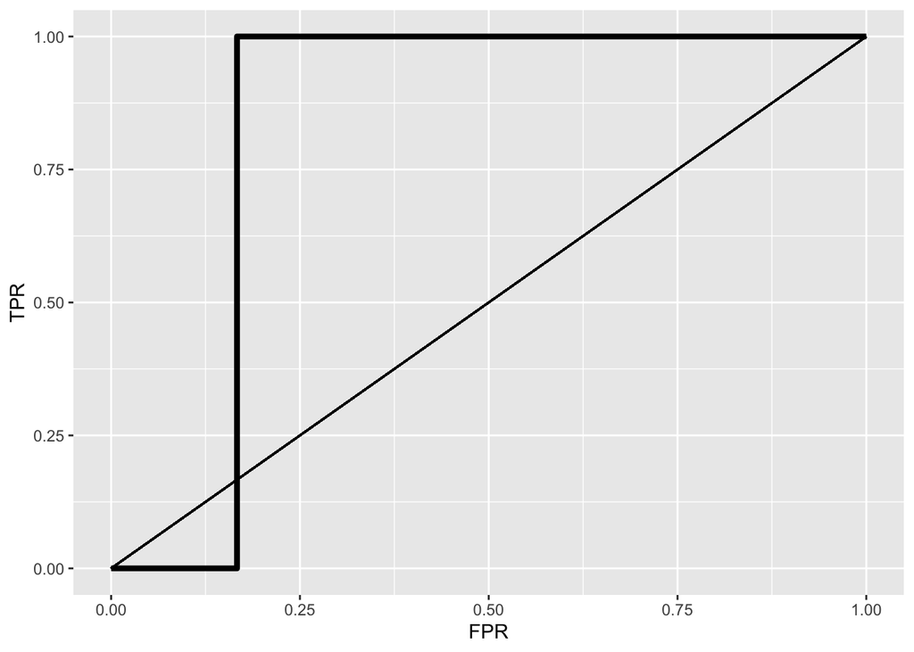

```r
#ROC Curve
marriage$prob<-predict(fit, type = "response")
sens<-function(p, data=marriage, y=highincome) mean(marriage[marriage$highincome==1,]$prob>p)
sensitivity<-sapply(seq(0,1,.01),sens,marriage)
spec<-function(p, data=marriage, y=highincome) mean(marriage[marriage$highincome==0,]$prob<p)
specificity<-sapply(seq(0,1,.01),spec,marriage)
ROC1<-data.frame(sensitivity,specificity,cutoff=seq(0,1,.01))

ROC1$TPR<-sensitivity
ROC1$FPR<-1-specificity

ROC1%>%ggplot(aes(FPR,TPR))+geom_path(size=1.5)+geom_segment(aes(x=0,y=0,xend=1,yend=1))+scale_x_continuous(limits = c(0,1))
```

```r
#AUC
ROC1<-ROC1[order(-ROC1$cutoff),]
widths<-diff(ROC1$FPR)
heights<-vector()
for(i in 1:100) heights[i]<-ROC1$TPR[i]+ROC1$TPR[i+1]
AUC<-sum(heights*widths/2)
AUC%>%round(3)
```

```
## [1] 0.833
```

```r
#k-fold
set.seed(1234)
k=5
data<-marriage[sample(nrow(marriage)),]
folds<-cut(seq(1:nrow(marriage)),breaks=k,labels=F)
diags<-NULL
for(i in k){
  train<-data[folds!=i,]
  test<-data[folds==i,]
  truth<-test$highincome
  fit<-glm(highincome~married.percent+nevermarried.percent, data=train,family = "binomial")
  prob<-predict(fit,newdata = test, type = "response")
  diags<-rbind(diags,class_diag(prob, truth))
}
summarize_all(diags,mean)
```

```
##   acc sens spec ppv auc
## 1   1    1    1   1   1
```

###Logistic regressions predict categorical variables. The highest income is predicted by married.percent and nevermarried.percent. The coefficient estimates show that controlling for percent never married, those with the highest income have 0.215 increase in odds of being married. Controlling for percent married, those with the highest income have 0.065 increase in odds of never being married. The coefficients also show the change in odds through e^(estimate), then these values can help interpret the logs odds and probabilities of the gender when added to the intercept. To test for accuracy, a confusion matrix was run. The accuracy of the logistic regression was 91.67%. The sensitivity or true positive rate (TPR) is 1, which is the probability of detecting if the individual has a high income. The specificity or true negative rate (TNR) is 0.833, which is the probability of testing that the individual has a low income. The precision (PPV) is the proportion of individuals who are have a high income. The PPV is 85.71%. The density plot shows the proportion of false negatives (FN) and false positives (FP). The false positives are shown in the gray area to the right of 0, where we predicted individuals to have a high income. The false negatives are shown in the gray area to the left of zero that we predicted to have a low income. A perfect prediction would have no overlaps, but perfectly centered left and right of 0. A perfect prediction for the ROC curve is when TPR=1, FPR=0, and AUC=1.The ROC curve shows that TPR and FPR have more randomized changes. This could be true by looking at the density plot, where the TP in the blue area is mostly above zero. This data is further shown by calculating the AUC in the ROC plot. The AUC is 0.833. This means that 83.3% of the time those who have a high income will have higher scores than those with a low income. This is a pretty good predictor. The k-fold test showed that the AUC is 1, which is a great predictor.

## LASSO Regression

```r
## lasso with linear regression (and numeric predictors)
library(glmnet)
y<-as.matrix(marriage$income.dollars)
x<-model.matrix(income.dollars~.,data = marriage)[,-1]
x<-scale(x)
cv<-cv.glmnet(x,y)
lasso<-glmnet(x,y,lambda=cv$lambda.1se)
coef(lasso)
```

```
## 14 x 1 sparse Matrix of class "dgCMatrix"
##                                   s0
## (Intercept)              46130.33333
## gendermale                  82.38582
## age.group20-34 years old  1329.34391
## age.group35-44 years old   868.47369
## age.group45-54 years old     .
## age.group55-64 years old     .
## age.group65 and older        .
## divorced.percent             .
## separated.percent            .
## nevermarried.percent     -7399.60342
## married.percent           1394.00571
## widowed.percent              .
## highincome                3357.37258
## prob                         .
```

```r
#MSE
fitmse<-lm(income.dollars~.,data = marriage)
yhat<-predict(fitmse)
mean((marriage$income.dollars-yhat)^2)
```

```
## [1] 4.41163e-23
```

```r
#cross validating from linear regression
set.seed(1234)
k=5
data<-marriage[sample(nrow(marriage)),]
folds<-cut(seq(1:nrow(marriage)),breaks=k,labels=F)
diags<-NULL

for(i in 1:k){
  train<-data[folds!=i,]
  test<-data[folds==i,]

  fit<-glm(income.dollars~., data = train)
 yhat<-predict(fit, newdata = test)
  diags<-mean((test$income.dollars-yhat)^2)
}
mean(diags)
```

```
## [1] 10800
```

```r
#cross validating from lasso
set.seed(1234)
k=5
data<-marriage[sample(nrow(marriage)),]
folds<-cut(seq(1:nrow(marriage)),breaks=k,labels=F)

diags<-NULL
for(i in 1:k){
  train<-data[folds!=i,]
  test<-data[folds==i,]

  fit<-glm(income.dollars~married.percent+nevermarried.percent+age.group+gender+highincome, data = train)
 yhat<-predict(fit, newdata = test)
  diags<-mean((test$income.dollars-yhat)^2)
}
mean(diags)
```

```
## [1] 10800
```